# Análisis del Dataset de Citas Rápidas

Oscar Méndez

2023-11-14

## Introducción

Este documento presenta un análisis detallado del dataset de citas rápidas. El objetivo es explorar diferentes aspectos de las citas rápidas, como la atracción, intereses compartidos y la percepción de los participantes.

## Carga y Exploración Inicial de los Datos

```r
speed_dating_data <- read.csv("../data/Speed Dating Data.csv")
kable(head(speed_dating_data), caption = "Primeras filas del dataset de citas rápidas.")
```

Primeras filas del dataset de citas rápidas.

| iid | id | gender | idg | condtn | wave | round | position | positin1 | order | partner | pid | match | int_corr | samerace | age_o | race_o | pf_o_att | pf_o_sin | pf_o_int | pf_o_fun | pf_o_amb | pf_o_sha | dec_o | attr_o | sinc_o | intel_o | fun_o | amb_o | shar_o | … |
| --- | --- | --- | --- | --- | --- | --- | --- | --- | --- | --- | --- | --- | --- | --- | --- | --- | --- | --- | --- | --- | --- | --- | --- | --- | --- | --- | --- | --- | --- | --- |
| 1 | 1 | 0 | 1 | 1 | 1 | 10 | 7 | NA | 4 | 1 | 11 | 0 | 0.14 | 0 | 27 | 2 | 35 | 20 | 20 | 20 | 0 | 5 | 0 | 6 | 8 | 8 | 8 | 8 | 6 | … |
| 1 | 1 | 0 | 1 | 1 | 1 | 10 | 7 | NA | 3 | 2 | 12 | 0 | 0.54 | 0 | 22 | 2 | 60 | 0 | 0 | 40 | 0 | 0 | 0 | 7 | 8 | 10 | 7 | 7 | 5 | … |
| 1 | 1 | 0 | 1 | 1 | 1 | 10 | 7 | NA | 10 | 3 | 13 | 1 | 0.16 | 1 | 22 | 4 | 19 | 18 | 19 | 18 | 14 | 12 | 1 | 10 | 10 | 10 | 10 | 10 | 10 | … |
| 1 | 1 | 0 | 1 | 1 | 1 | 10 | 7 | NA | 5 | 4 | 14 | 1 | 0.61 | 0 | 23 | 2 | 30 | 5 | 15 | 40 | 5 | 5 | 1 | 7 | 8 | 9 | 8 | 9 | 8 | … |
| 1 | 1 | 0 | 1 | 1 | 1 | 10 | 7 | NA | 7 | 5 | 15 | 1 | 0.21 | 0 | 24 | 3 | 30 | 10 | 20 | 10 | 10 | 20 | 1 | 8 | 7 | 9 | 6 | 9 | 7 | … |
| 1 | 1 | 0 | 1 | 1 | 1 | 10 | 7 | NA | 6 | 6 | 16 | 0 | 0.25 | 0 | 25 | 2 | 50 | 0 | 30 | 10 | 0 | 10 | 1 | 7 | 7 | 8 | 8 | 7 | 7 | … |

## Análisis de Matches

Exploramos el porcentaje de matches exitosos en el dataset.

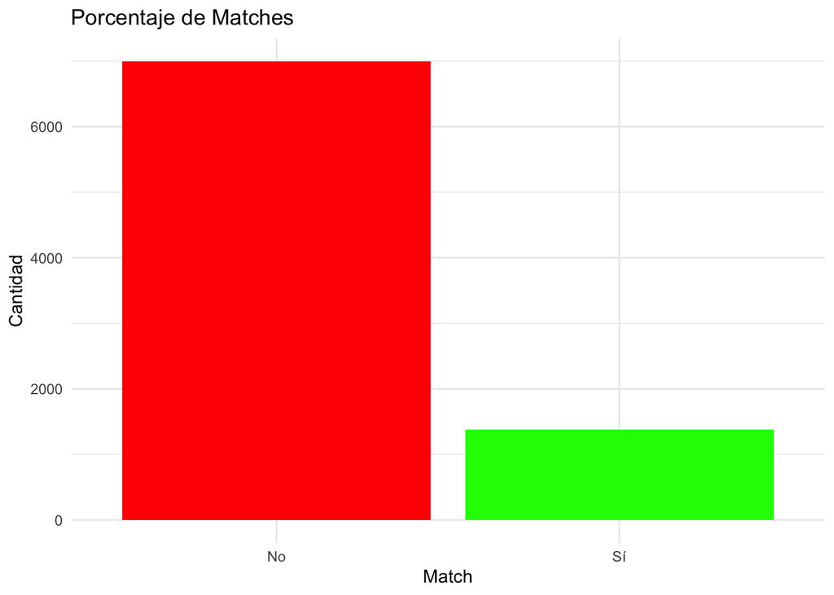

```r
total_dates <- nrow(speed_dating_data)
matches <- sum(speed_dating_data$match == 1)
match_percentage <- (matches / total_dates) * 100

# Visualización del porcentaje de matches
library(ggplot2)
ggplot(data.frame(Match=c("Sí", "No"), Count=c(matches, total_dates - matches)), aes(x=Match, y=Count)) +
  geom_bar(stat="identity", fill=c("green", "red")) +
  labs(title="Porcentaje de Matches", x="Match", y="Cantidad") +
  theme_minimal()
```

## Evaluación de Atributos por Género

Analizamos cómo los diferentes atributos son valorados por género.

```r
library(dplyr)
attributes <- c("attr", "sinc", "intel", "fun", "amb", "shar")
attributes_desirability <- speed_dating_data %>%
  group_by(gender) %>%
  summarise(across(all_of(attributes), mean, na.rm = TRUE))
# Visualización de atributos menos deseados por género
library(reshape2)
```

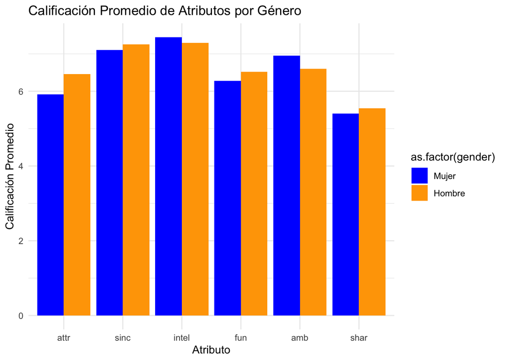

```r
attributes_desirability_long <- melt(attributes_desirability, id.vars = "gender")
ggplot(attributes_desirability_long, aes(x=variable, y=value, fill=as.factor(gender))) +
  geom_bar(stat="identity", position=position_dodge()) +
  scale_fill_manual(values=c("blue", "orange"), labels=c("Mujer", "Hombre")) +
  labs(title="Calificación Promedio de Atributos por Género", x="Atributo", y="Calificación Promedio") +
  theme_minimal()
```

## Importancia de la Atracción Física

Comparamos la importancia de la atracción física desde la perspectiva de autoevaluación y la evaluación de la cita.

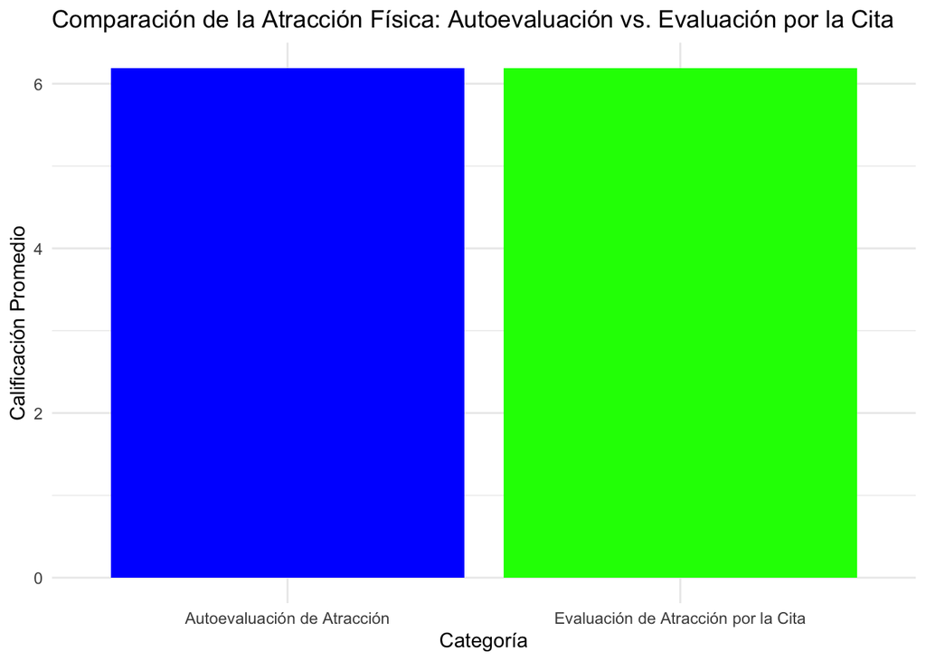

```r
attraction_importance <- colMeans(speed_dating_data[, c("attr", "attr_o")], na.rm = TRUE)

# Visualización de la importancia de la atracción física
attraction_data <- data.frame(
  Category = c("Autoevaluación de Atracción", "Evaluación de Atracción por la Cita"),
  Score = c(attraction_importance['attr'], attraction_importance['attr_o'])
)

ggplot(attraction_data, aes(x = Category, y = Score, fill = Category)) +
  geom_bar(stat = "identity", show.legend = FALSE) +
  scale_fill_manual(values = c("blue", "green")) +
  labs(title = "Comparación de la Atracción Física: Autoevaluación vs. Evaluación por la Cita",
       x = "Categoría",
       y = "Calificación Promedio") +
  theme_minimal()
```

## Influencia de Intereses Compartidos

Analizamos la influencia de intereses compartidos en la decisión de los participantes de querer verse nuevamente.

```r
library(dplyr)

shared_interests <- speed_dating_data %>%
  group_by(dec, dec_o) %>%
  summarise(mean_shar = mean(shar, na.rm = TRUE))
```

[output not shown]

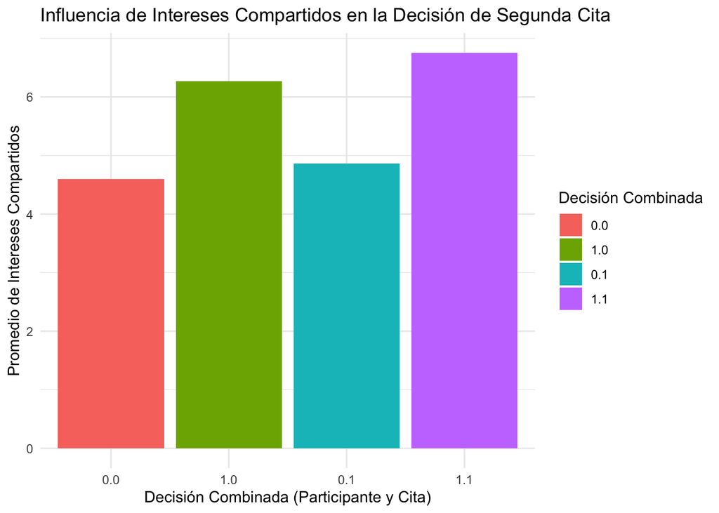

```r
# Visualización de la influencia de intereses compartidos
ggplot(shared_interests, aes(x=interaction(dec, dec_o), y=mean_shar, fill=interaction(dec, dec_o))) +
  geom_col() +
  labs(title="Influencia de Intereses Compartidos en la Decisión de Segunda Cita",
       x="Decisión Combinada (Participante y Cita)",
       y="Promedio de Intereses Compartidos",
       fill="Decisión Combinada") +
  theme_minimal()
```

## Auto-percepción vs. Percepción de los Demás

Investigamos cómo los participantes se perciben a sí mismos en comparación con cómo son percibidos por otros en términos de atracción.

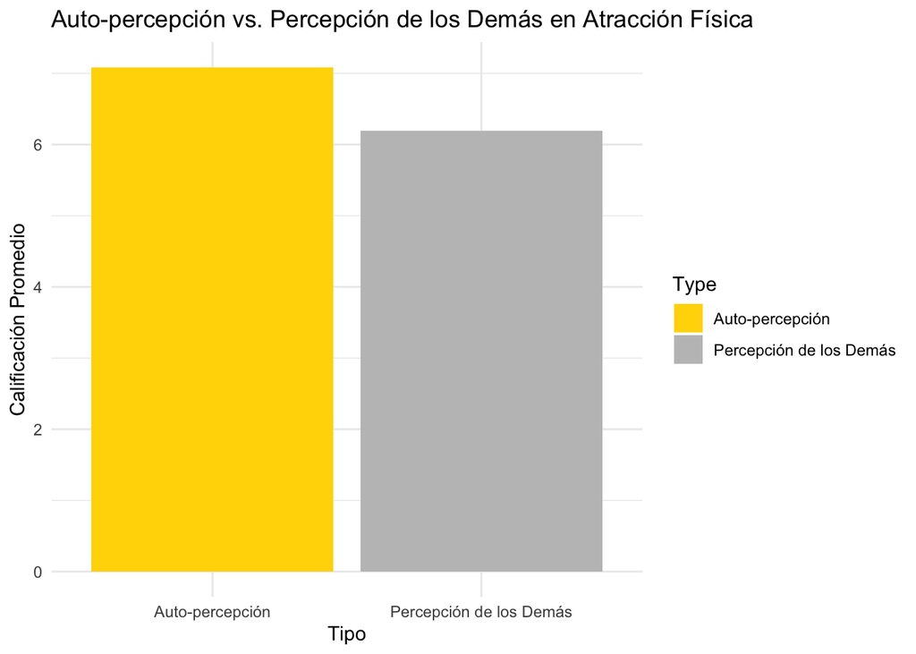

```r
self_perception <- colMeans(speed_dating_data[, c("attr3_1", "attr")], na.rm = TRUE)

# Datos para visualización
perception_data <- data.frame(
  Type = c("Auto-percepción", "Percepción de los Demás"),
  Score = c(self_perception['attr3_1'], self_perception['attr'])
)

# Visualización de auto-percepción vs. percepción de los demás
perception_data <- data.frame(Type=c("Auto-percepción", "Percepción de los Demás"),
                              Score=c(self_perception['attr3_1'], self_perception['attr']))
ggplot(perception_data, aes(x=Type, y=Score, fill=Type)) +
  geom_bar(stat="identity") +
  scale_fill_manual(values=c("#FFD700", "#C0C0C0")) + # Códigos hexadecimales para gold y silver
  labs(title="Auto-percepción vs. Percepción de los Demás en Atracción Física",
       x="Tipo", y="Calificación Promedio") +
  theme_minimal()
```

## Efecto del Orden de la Cita

Examinamos cómo el orden de la cita durante el evento de speed dating afecta la probabilidad de que los participantes quieran una segunda cita.

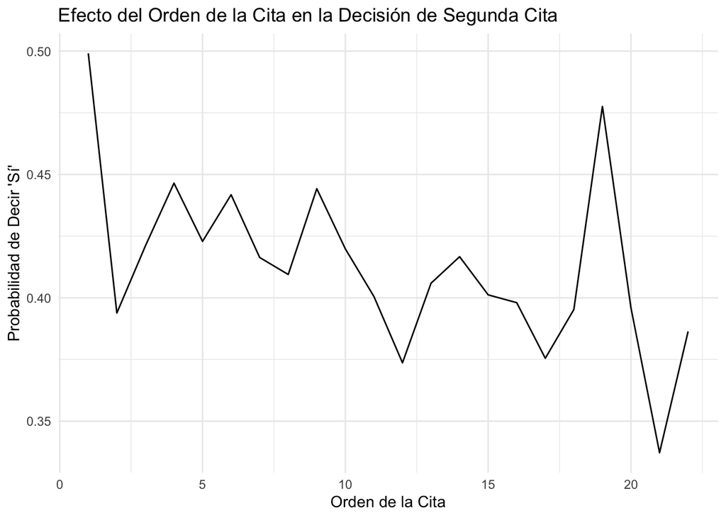

```r
date_order_effect <- aggregate(dec ~ order, speed_dating_data, mean)

# Visualización del efecto del orden de la cita
ggplot(date_order_effect, aes(x = order, y = dec)) +
  geom_line() +
  labs(title = "Efecto del Orden de la Cita en la Decisión de Segunda Cita",
       x = "Orden de la Cita",
       y = "Probabilidad de Decir 'Sí'") +
  theme_minimal()
```

## Interpretación de Resultados

### Distribución de Edades por Género

La distribución de edades muestra una variedad de participantes en diferentes rangos de edad, tanto para hombres como para mujeres. Ambos géneros presentan una distribución similar, con una concentración más alta en ciertos rangos de edad, probablemente alrededor de los 20 a 30 años.

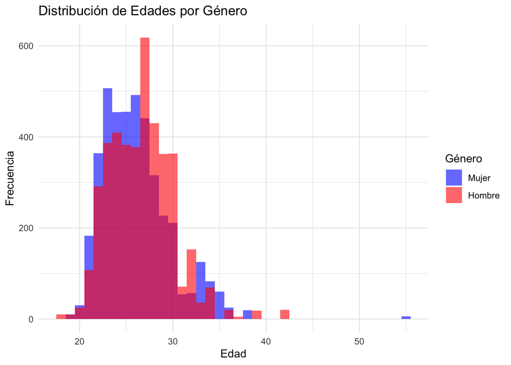

### Porcentaje de Matches (16.47%)

Este porcentaje sugiere que solo una minoría de las citas resultaron en un interés mutuo para una segunda cita. Esto puede reflejar la complejidad de encontrar una conexión significativa en un entorno de citas rápidas o indicar que las primeras impresiones en un período corto no siempre conducen a un interés romántico sostenido.

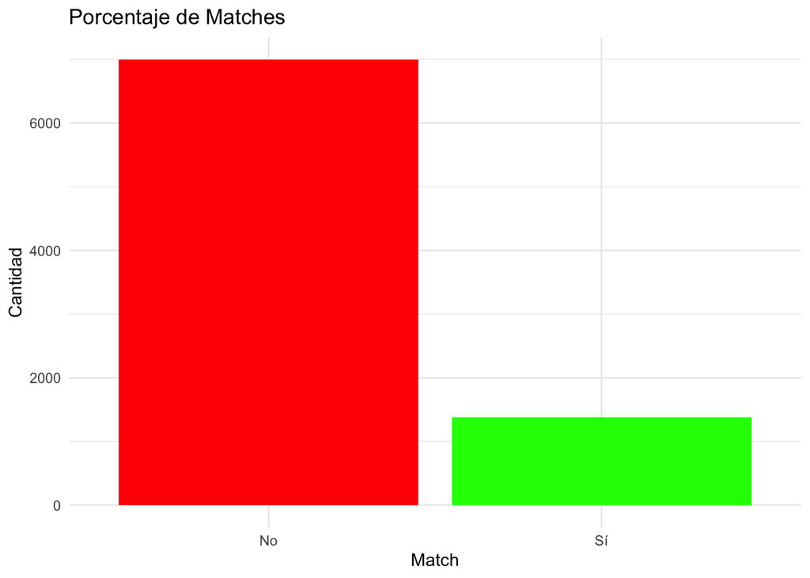

### Atributos Menos Deseados por Género

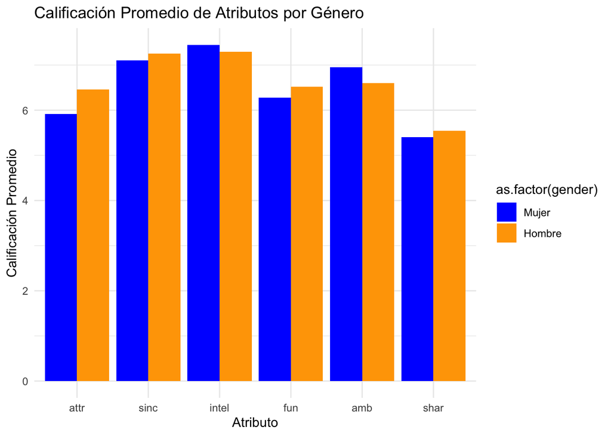

### Auto-percepción vs. Percepción de los Demás

La auto-percepción de los participantes sobre su propia atracción es ligeramente más alta (promedio de 7.08) que cómo los demás los perciben en términos de atracción física, con un promedio de 6.19. Esto podría reflejar un sesgo de optimismo en la autoevaluación o una discrepancia entre la autoimagen y la percepción externa.

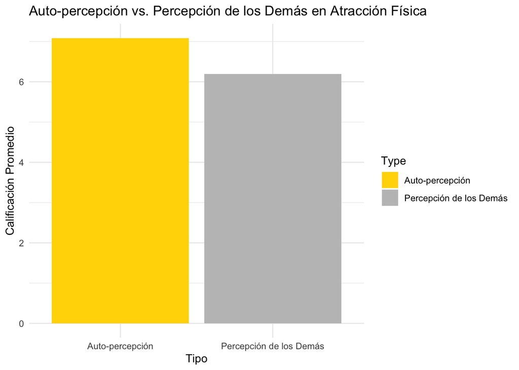

### Importancia de la Atracción Física

La similitud en las puntuaciones de atracción física autoevaluadas y evaluadas por la cita (alrededor de 6.19) indica una consistencia en la percepción de la importancia de la atracción física. Esto refuerza la idea de que la atracción física es un factor crítico en la selección de pareja en este contexto.

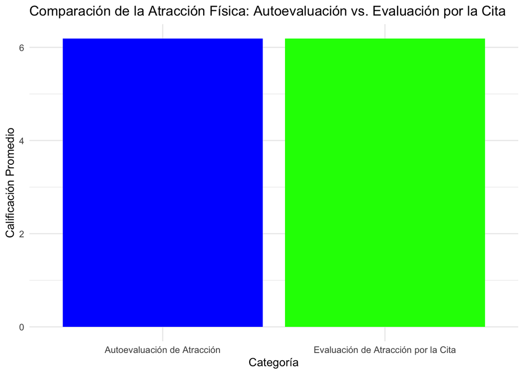

### Influencia de Intereses Compartidos

La correlación entre los intereses compartidos y el deseo de una segunda cita es más fuerte cuando ambos participantes están interesados en volver a verse. Esto sugiere que, aunque los intereses compartidos pueden no ser el factor más crucial en una primera impresión, se vuelven significativos cuando hay un interés mutuo.

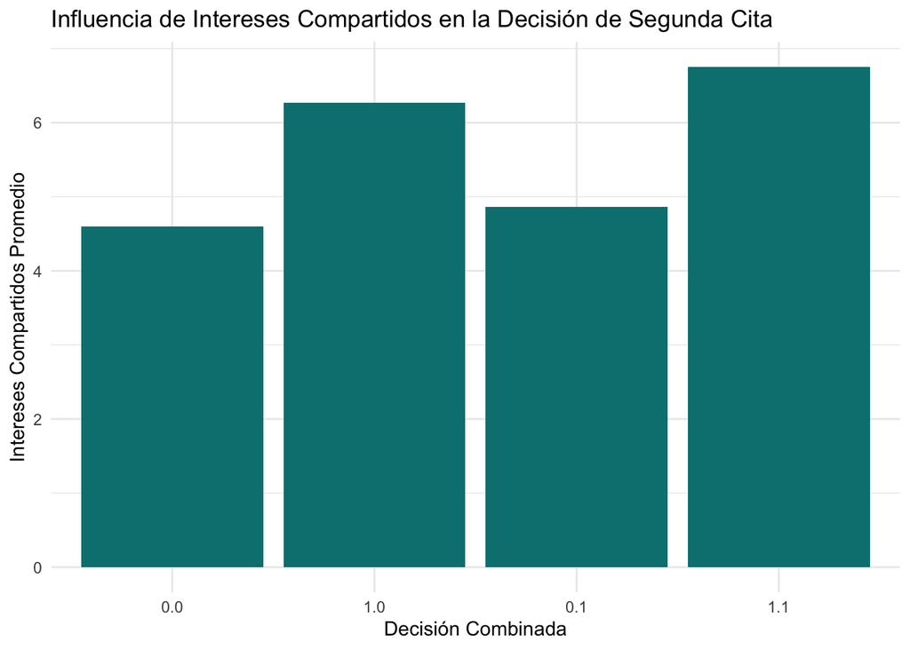

### Calificaciones Promedio de Atributos por Género

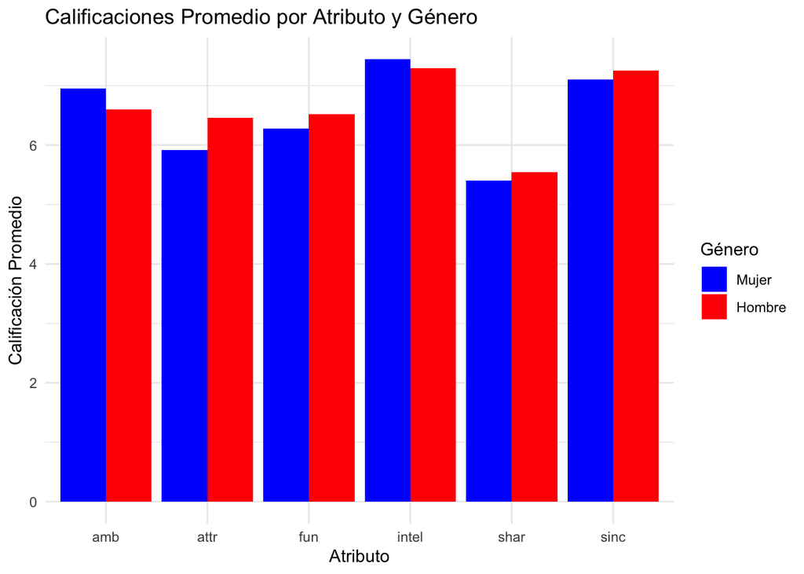

### Decisión de Segunda Cita: Primera vs. Última Cita

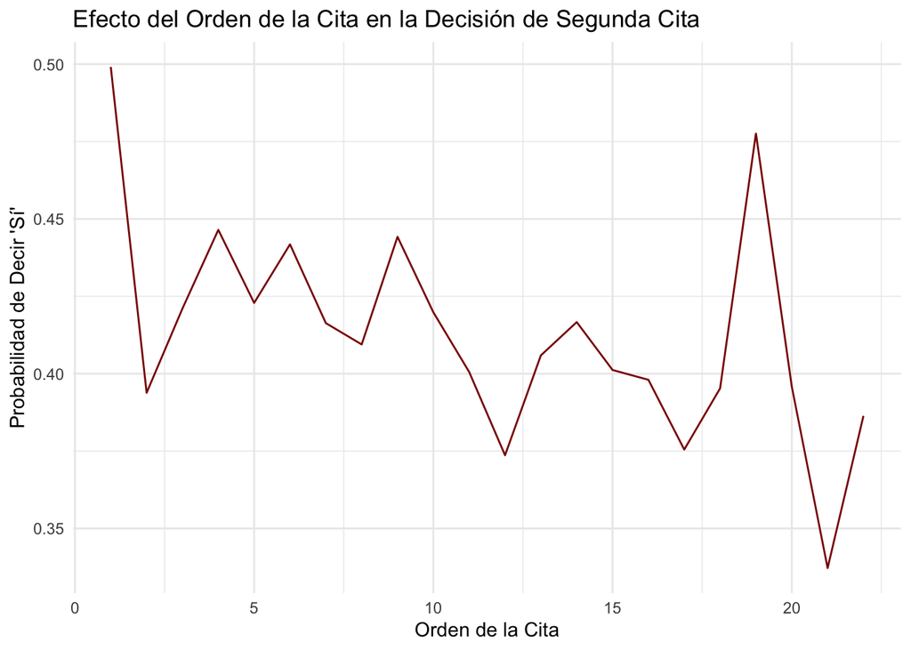